# PCSF: Kylie Data, STRING

2023-06-02

## Description

The genes in this pipeline are those identified to be differentially expressed (DE) in stage_I, stage_II, stage_III and stage_IV samples. Run with interaction data from DE gene list in STRING. In this run, no cutoff is used for DE genes i.e. -3 to 3 (used all DE genes).

See end of doc for gene subset summary

**Show Kylie raw data treatment**

```r
sample_info <- read.csv("raw_data/All survival_CN_Aug18.csv")
sample_info <- subset(sample_info, select = c("GAMUT_ID", "Grade", "Stage"))

kylie_counts <- read.csv("raw_data/analysis_set_raw_counts.csv", row.names = 1)

# Extract column names
column_names <- colnames(kylie_counts)

# Remove "GAMuT_" part from column names
gamut_ids <- sub("^GAMuT_", "", column_names)


# create list of stage ids
stage_I <- c("I","IA","IB","IC")
stage_II <- c("II", "IIA", "IIB", "IIC")
stage_III <- c("III", "IIIA", "IIIB", "IIIC", "IIIc")
stage_IV <- c("IV")
stage_ids <- list(stage_I, stage_II, stage_III, stage_IV)

# common GAMuT IDs between sample_info and kylie_counts
matching_ids <- intersect(gamut_ids, sample_info$GAMUT_ID)

stage_df <- list()

for (stage in stage_ids) {
  # sanity check
  print(stage)
  # retrieve GAMuT ID for the stage
  stage_id <- sample_info[sample_info$Stage %in% stage, 1]
  # common GAMuT IDs between stage and matching_ids
  matching_stage_id <- intersect(matching_ids, stage_id)
  # subset the kylie_counts df based on the IDs from matching_stage_id
  subset_stage_counts <- kylie_counts[, paste0("GAMuT_", matching_stage_id)]
  # add it to the df list
  stage_df <- c(stage_df, list(subset_stage_counts))
}

# retrieve each df from the list and save a separate variable
stage_I <- stage_df[[1]]
stage_II <- stage_df[[2]]
stage_III <- stage_df[[3]]
stage_IV <- as.data.frame(stage_df[[4]])
colnames(stage_IV) <- paste0("GAMuT_", matching_stage_id)
rownames(stage_IV) <- rownames(kylie_counts)


write.csv(stage_I, "rna_seq_data/stage_I_master_df.csv")
write.csv(stage_II, "rna_seq_data/stage_II_master_df.csv")
write.csv(stage_III, "rna_seq_data/stage_III_master_df.csv")
write.csv(stage_IV, "rna_seq_data/stage_IV_master_df.csv")


## subset benign samples
ben_rows <- subset(sample_info, Grade == "BEN")
ben_id <- ben_rows$GAMUT_ID
matching_ben_id <- intersect(matching_ids, ben_id)
subset_ben_counts <- kylie_counts[, paste0("GAMuT_", matching_ben_id)]

#write.csv(subset_ben_counts, "rna_seq_data/ben_master_df.csv")

#bdl_rows <- subset(sample_info, Grade == "BDL")
```

### Gene Subset Progression

- Stage_I = 36
- Stage_II = 2 files
- Stage_III = 5 files
- Stage_IV = 1 files
- Benign = 12

**Show calc**

```r
# combine stage I, II, III and IV
stage_I <- read.csv("rna_seq_data/stage_I_master_df.csv")
stage_II <- read.csv("rna_seq_data/stage_II_master_df.csv")
stage_III <- read.csv("rna_seq_data/stage_III_master_df.csv")
stage_IV <- read.csv("rna_seq_data/stage_IV_master_df.csv")

kylie_data <- merge(stage_I, stage_II, by = "X")
kylie_data <- merge(kylie_data, stage_III, by = "X")
kylie_data <- merge(kylie_data, stage_IV, by = "X")

raw_gene_list <- nrow(kylie_data)

colnames(kylie_data)[1] <- "gene_id"
gene_id <- kylie_data$gene_id
kylie_data <- kylie_data[, -1] # remove gene ids for rowSums calc

# subset genes that have a cpm of greater than one in more than 50% of the samples
keepTheseGenes <- (rowSums(cpm(kylie_data) > 1) >= ncol(kylie_data)/2)
print(summary(keepTheseGenes))
```

```
##    Mode   FALSE    TRUE
## logical      24   14865
```

```r
# add gene ids back into df
kylie_data <- cbind(gene_id, kylie_data)

removedGenes <- kylie_data$gene_id[!keepTheseGenes]
removedGenes <- as.data.frame(removedGenes)
colnames(removedGenes)[1] <- "gene_id"

kylie_data <- kylie_data[keepTheseGenes, ]

initial_subset <- nrow(kylie_data)
```

Low count genes

| ensembl_gene_id | external_gene_name |
| --- | --- |
| ENSG00000078549 | ADCYAP1R1 |
| ENSG00000096006 | CRISP3 |
| ENSG00000115386 | REG1A |
| ENSG00000133134 | BEX2 |
| ENSG00000137745 | MMP13 |
| ENSG00000141469 | SLC14A1 |
| ENSG00000141837 | CACNA1A |
| ENSG00000154646 | TMPRSS15 |
| ENSG00000156234 | CXCL13 |
| ENSG00000157551 | KCNJ15 |
| ENSG00000163631 | ALB |
| ENSG00000166405 | RIC3 |
| ENSG00000169245 | CXCL10 |
| ENSG00000169605 | GKN1 |
| ENSG00000170893 | TRH |
| ENSG00000174992 | ZG16 |
| ENSG00000175084 | DES |
| ENSG00000183607 | GKN2 |
| ENSG00000197888 | UGT2B17 |
| ENSG00000198483 | ANKRD35 |
| ENSG00000256713 | PGA5 |
| ENSG00000262074 | SNORD3B-2 |
| ENSG00000263961 | RHEX |
| ENSG00000269404 | SPIB |

## Step 1: Differential expression analysis using edgeR

```
## Disp = 0.38802 , BCV = 0.6229
```

```
##        groupcancer
## Down           124
## NotSig       14081
## Up             660
```

**Show non-sig diff exp genes**

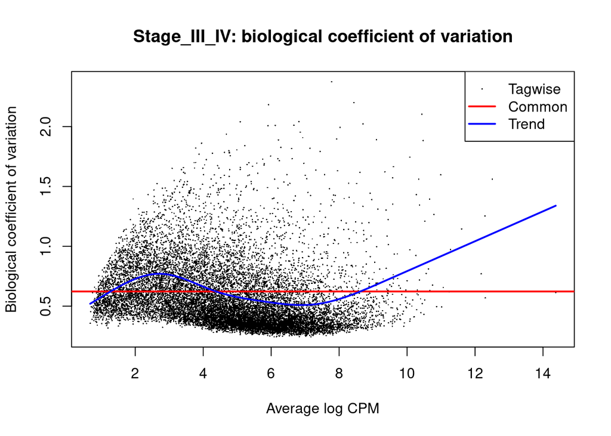

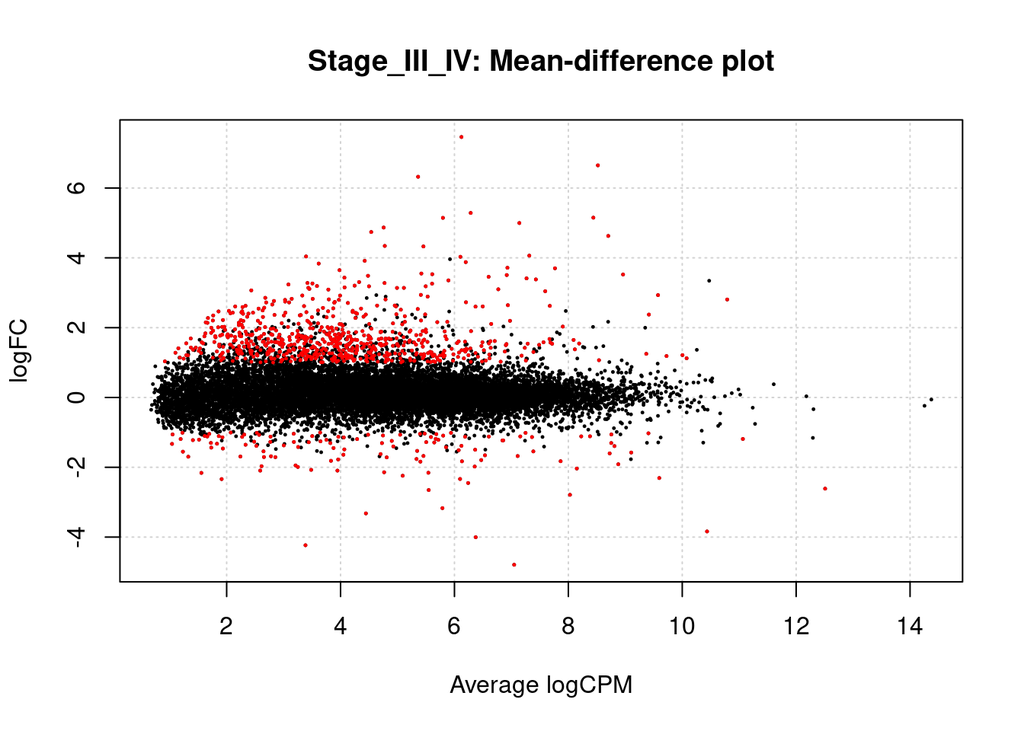

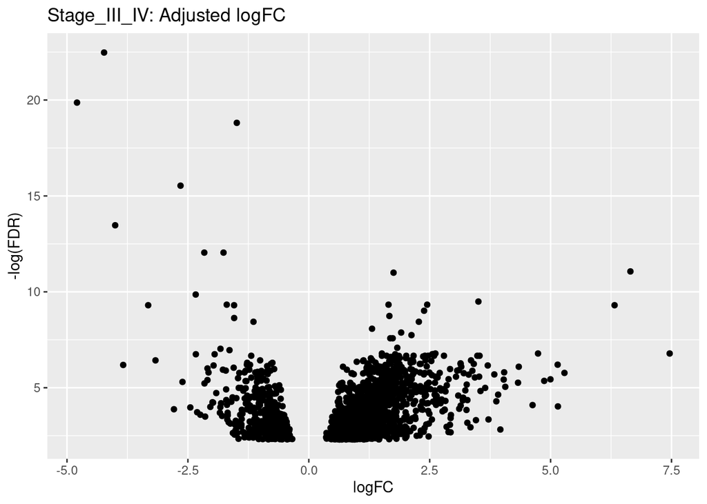

## Step 2: PCSF file prep - Create score file and format STRING interaction data

- Convert gene ensembl to gene symbol
- Create score file from logFC values
- Feed list of proteins into STRING/Cytoscape
- Format output and create interaction file

**Show code + removed genes**

```r
# subset highly differentially expressed genes and create Cytoscape files

# read in the data
kylie_data <- read.csv("edgeR/edgeR_dif_exp_genes.csv")

# subset the gene_id and logFC columns
kylie_data <- subset(kylie_data, select = c("gene_id", "logFC"))

#hist(kylie_data$logFC, main = "Stage_III_IV Fold Change")


# skipped this step because subset differentially expressed genes from edgeR step

## remove all values with logFC between whatever range ya want
#kylie_data$logFC <- ifelse(kylie_data$logFC > -3 & kylie_data$logFC < 3, NA, kylie_data$logFC)
#low_logFC <- subset(kylie_data, is.na(logFC))
#kylie_data <- na.omit(kylie_data)
#
#low_logFC <- getBM(attributes = c("ensembl_gene_id", "external_gene_name"),
#                       filters = "ensembl_gene_id",
#                       values = low_logFC$gene_id,
#                       mart = ensembl)
#
#kable(low_logFC, format = "html", caption = "Removed genes from -3 to 3 cutoff") %>%
#kable_styling(full_width = FALSE) %>%
#scroll_box(height = "400px")
```

```r
# convert to gene symbol
kylie_uniprot_id <- getBM(attributes = c("ensembl_gene_id", "external_gene_name"),
                       filters = "ensembl_gene_id",
                       values = kylie_data$gene_id,
                       mart = ensembl)

# remove empty rows
kylie_uniprot_id <- subset(kylie_uniprot_id, external_gene_name != "") # uniprot_gn_symbol = 772

# check for duplicate uniprot ids
kylie_uniprot_id <- distinct(kylie_uniprot_id)

# merge back with original data
colnames(kylie_uniprot_id)[1] <- "gene_id"

kylie_uniprot_data <- merge(kylie_uniprot_id, kylie_data, by = "gene_id")

kylie_uniprot_data <- subset(kylie_uniprot_data, select = c("external_gene_name", "logFC"))

# check to see if genes that at all genes were converted at least once
missing_genes <- anti_join(kylie_data, kylie_uniprot_id, by = "gene_id")

# create score file
write.csv(kylie_uniprot_data, "string_run/pcsf_kylie_score.csv")
#
## create ensemble protein list for interaction db
write.table(kylie_data$external_gene_name, "string_run/kylie_gene_list.txt", row.names = F, col.names = F, quote = F)
```

```r
string_edge_data <- read.table("string_run/STRING network (physical) default edge.csv", header = T, sep = ",", stringsAsFactors = F)
ppi_list <- subset(string_edge_data, select = c("name", "stringdb..score"))
ppi_list <- ppi_list %>%
  separate(name, sep = " ", into = c("node_1", "del", "node_2"))
ppi_list <- subset(ppi_list, select = c("node_1", "node_2", "stringdb..score"))
ppi_list$node_1 <- gsub(".*.\\.", "", ppi_list$node_1)
ppi_list$node_2 <- gsub(".*.\\.", "", ppi_list$node_2)

string_node_data <- read.table("string_run/STRING network (physical) default node.csv", header = T, sep = ",", stringsAsFactors = F)
node_list <- subset(string_node_data, select = c("name", "query.term"))
node_list$name <- gsub(".*.\\.", "", node_list$name)
ppi_list$original_order <- seq_len(nrow(ppi_list))
merged_df <- merge(ppi_list, node_list, by.x = "node_1", by.y = "name", all.x = TRUE)
merged_df <- merge(merged_df, node_list, by.x = "node_2", by.y = "name", all.x = TRUE)
merged_df <- merged_df[order(merged_df$original_order), ]

final_df <- merged_df[, c("query.term.x", "query.term.y", "stringdb..score")]
colnames(final_df) <- c("node_1", "node_2", "score")

write.csv(final_df, "string_run/interaction_score.csv")


# create gene_id uniprot_id ref list.
ref_list <- getBM(attributes = c("external_gene_name","uniprot_gn_id"),
                  filters = "external_gene_name",
                  values = node_list$query.term,
                  mart = ensembl)


write.table(ref_list$external_gene_name, "string_run/string_gene_names.csv", quote = F, row.names = F, col.names = F)
```

## Step 3: Run PCSF and create cross reference results with AF structures for durggability

```
##   45.19% of your terminal nodes are included in the interactome
##   Solving the PCSF by adding random noise to the edge costs...
```

```
## Time difference of 2.219685 secs
```

[interactive chart not shown]

Note: The citation scores for this data were generated outside this R script using PubMed API

**Show raw table**

PCSF Druggability Results

| external_gene_name | uniprot_gn_id | ID | cluster | betweenness | degree_centrality | pocket | druggability | num_drug_pockets | struct_score | logFC | regulation | citation_score |
| --- | --- | --- | --- | --- | --- | --- | --- | --- | --- | --- | --- | --- |
| MUC17 | Q685J3 | Q685J3-F12 | 3 | 0 | 1 | 0.130 | 1.000 | 3 | 55.24057 | 2.932096 | up_reg | 99 |
| MUC17 | Q685J3 | Q685J3-F5 | 3 | 0 | 1 | 0.317 | 1.000 | 7 | 50.38741 | 2.932096 | up_reg | 99 |
| MUC17 | Q685J3 | Q685J3-F3 | 3 | 0 | 1 | 0.321 | 1.000 | 5 | 57.04810 | 2.932096 | up_reg | 99 |
| MUC17 | Q685J3 | Q685J3-F2 | 3 | 0 | 1 | 0.338 | 0.999 | 8 | 53.74200 | 2.932096 | up_reg | 99 |
| MUC17 | Q685J3 | Q685J3-F10 | 3 | 0 | 1 | 0.303 | 0.998 | 8 | 57.31370 | 2.932096 | up_reg | 99 |
| MUC17 | Q685J3 | Q685J3-F11 | 3 | 0 | 1 | 0.223 | 0.998 | 4 | 55.80117 | 2.932096 | up_reg | 99 |
| MUC17 | Q685J3 | Q685J3-F13 | 3 | 0 | 1 | 0.184 | 0.998 | 9 | 52.17108 | 2.932096 | up_reg | 99 |
| CENPE | Q02224 | Q02224-F6 | 2 | 0 | 1 | 0.135 | 0.997 | 5 | 72.55249 | 1.269516 | up_reg | 436 |
| MUC17 | Q685J3 | Q685J3-F7 | 3 | 0 | 1 | 0.253 | 0.996 | 7 | 51.47074 | 2.932096 | up_reg | 99 |
| MUC17 | Q685J3 | Q685J3-F1 | 3 | 0 | 1 | 0.162 | 0.996 | 6 | 51.86692 | 2.932096 | up_reg | 99 |
| CD9 | P21926 | P21926-F1 | 3 | 194 | 6 | 0.063 | 0.994 | 1 | 88.11915 | 1.197630 | up_reg | 2701 |
| MELK | Q14680 | Q14680-F1 | 2 | 0 | 1 | 0.159 | 0.993 | 1 | 70.64372 | 1.752877 | up_reg | 658 |
| MUC17 | Q685J3 | Q685J3-F6 | 3 | 0 | 1 | 0.273 | 0.993 | 5 | 57.70932 | 2.932096 | up_reg | 99 |
| MUC17 | Q685J3 | Q685J3-F17 | 3 | 0 | 1 | 0.018 | 0.993 | 2 | 52.40577 | 2.932096 | up_reg | 99 |
| XPR1 | Q9UBH6 | Q9UBH6-F1 | 2 | 0 | 1 | 0.207 | 0.993 | 3 | 83.73372 | 1.315627 | up_reg | 176 |
| KIF11 | P52732 | P52732-F1 | 2 | 293 | 4 | 0.141 | 0.991 | 1 | 74.76864 | 1.235773 | up_reg | 818 |
| PTGS2 | P35354 | P35354-F1 | 2 | 256 | 2 | 0.262 | 0.987 | 1 | 93.32770 | 2.328627 | up_reg | 41091 |
| TEAD4 | Q15561 | Q15561-F1 | 2 | 0 | 1 | 0.243 | 0.986 | 2 | 76.58312 | 1.595021 | up_reg | 380 |
| FABP1 | P07148 | P07148-F1 | 2 | 0 | 1 | -0.023 | 0.981 | 1 | 94.95010 | 7.462078 | up_reg | 893 |
| ABCA2 | Q9BZC7 | Q9BZC7-F1 | 2 | 3146 | 2 | 0.258 | 0.976 | 5 | 72.33891 | 1.258590 | up_reg | 138 |
| PRC1 | O43663 | O43663-F1 | 2 | 0 | 1 | 0.226 | 0.975 | 2 | 80.11427 | 1.455688 | up_reg | 1521 |
| SPAG4 | Q9NPE6 | Q9NPE6-F1 | 2 | 0 | 1 | 0.378 | 0.975 | 1 | 71.56424 | 1.517835 | up_reg | 51 |
| KIF20B | Q96Q89 | Q96Q89-F1 | 2 | 0 | 2 | 0.232 | 0.971 | 4 | 63.74834 | 1.018508 | up_reg | 56 |
| H2BC10 | P62807 | P62807-F1 | 2 | 5961 | 14 | 0.291 | 0.965 | 1 | 87.82973 | 1.197421 | up_reg | 0 |
| H2BC4 | P62807 | P62807-F1 | 2 | 386 | 9 | 0.291 | 0.965 | 1 | 87.82973 | 1.120676 | up_reg | 0 |
| H2BC6 | P62807 | P62807-F1 | 2 | 3612 | 15 | 0.291 | 0.965 | 1 | 87.82973 | 1.511202 | up_reg | 0 |
| H2BC7 | P62807 | P62807-F1 | 2 | 5693 | 14 | 0.291 | 0.965 | 1 | 87.82973 | 1.648263 | up_reg | 0 |
| H2BC8 | P62807 | P62807-F1 | 2 | 1806 | 14 | 0.291 | 0.965 | 1 | 87.82973 | 1.313233 | up_reg | 1 |
| CENPE | Q02224 | Q02224-F2 | 2 | 0 | 1 | 0.126 | 0.960 | 2 | 70.76444 | 1.269516 | up_reg | 436 |
| DNAH3 | Q8TD57 | Q8TD57-F4 | 7 | 0 | 1 | 0.164 | 0.960 | 4 | 85.66639 | 2.301795 | up_reg | 16 |

[output cut: 382 more lines]

Note: Duplicates removed here

PCSF Druggability Results

| external_gene_name | uniprot_gn_id | ID | cluster | betweenness | degree_centrality | pocket | druggability | num_drug_pockets | struct_score | logFC | regulation | citation_score |
| --- | --- | --- | --- | --- | --- | --- | --- | --- | --- | --- | --- | --- |
| MUC17 | Q685J3 | Q685J3-F12 | 3 | 0 | 1 | 0.130 | 1.000 | 3 | 55.24057 | 2.932096 | up_reg | 99 |
| CENPE | Q02224 | Q02224-F6 | 2 | 0 | 1 | 0.135 | 0.997 | 5 | 72.55249 | 1.269516 | up_reg | 436 |
| CD9 | P21926 | P21926-F1 | 3 | 194 | 6 | 0.063 | 0.994 | 1 | 88.11915 | 1.197630 | up_reg | 2701 |
| MELK | Q14680 | Q14680-F1 | 2 | 0 | 1 | 0.159 | 0.993 | 1 | 70.64372 | 1.752877 | up_reg | 658 |
| XPR1 | Q9UBH6 | Q9UBH6-F1 | 2 | 0 | 1 | 0.207 | 0.993 | 3 | 83.73372 | 1.315627 | up_reg | 176 |
| KIF11 | P52732 | P52732-F1 | 2 | 293 | 4 | 0.141 | 0.991 | 1 | 74.76864 | 1.235773 | up_reg | 818 |
| PTGS2 | P35354 | P35354-F1 | 2 | 256 | 2 | 0.262 | 0.987 | 1 | 93.32770 | 2.328627 | up_reg | 41091 |
| TEAD4 | Q15561 | Q15561-F1 | 2 | 0 | 1 | 0.243 | 0.986 | 2 | 76.58312 | 1.595021 | up_reg | 380 |
| FABP1 | P07148 | P07148-F1 | 2 | 0 | 1 | -0.023 | 0.981 | 1 | 94.95010 | 7.462078 | up_reg | 893 |
| ABCA2 | Q9BZC7 | Q9BZC7-F1 | 2 | 3146 | 2 | 0.258 | 0.976 | 5 | 72.33891 | 1.258590 | up_reg | 138 |
| PRC1 | O43663 | O43663-F1 | 2 | 0 | 1 | 0.226 | 0.975 | 2 | 80.11427 | 1.455688 | up_reg | 1521 |
| SPAG4 | Q9NPE6 | Q9NPE6-F1 | 2 | 0 | 1 | 0.378 | 0.975 | 1 | 71.56424 | 1.517835 | up_reg | 51 |
| KIF20B | Q96Q89 | Q96Q89-F1 | 2 | 0 | 2 | 0.232 | 0.971 | 4 | 63.74834 | 1.018508 | up_reg | 56 |
| H2BC10 | P62807 | P62807-F1 | 2 | 5961 | 14 | 0.291 | 0.965 | 1 | 87.82973 | 1.197421 | up_reg | 0 |
| H2BC4 | P62807 | P62807-F1 | 2 | 386 | 9 | 0.291 | 0.965 | 1 | 87.82973 | 1.120676 | up_reg | 0 |
| H2BC6 | P62807 | P62807-F1 | 2 | 3612 | 15 | 0.291 | 0.965 | 1 | 87.82973 | 1.511202 | up_reg | 0 |
| H2BC7 | P62807 | P62807-F1 | 2 | 5693 | 14 | 0.291 | 0.965 | 1 | 87.82973 | 1.648263 | up_reg | 0 |
| H2BC8 | P62807 | P62807-F1 | 2 | 1806 | 14 | 0.291 | 0.965 | 1 | 87.82973 | 1.313233 | up_reg | 1 |
| DNAH3 | Q8TD57 | Q8TD57-F4 | 7 | 0 | 1 | 0.164 | 0.960 | 4 | 85.66639 | 2.301795 | up_reg | 16 |
| RARA | P10276 | P10276-F1 | 2 | 1096 | 15 | 0.362 | 0.958 | 1 | 79.41892 | 1.489489 | up_reg | 4395 |
| CYBA | P13498 | P13498-F1 | 2 | 1015 | 3 | 0.480 | 0.957 | 1 | 77.02989 | 1.272987 | up_reg | 1043 |
| H2BC17 | P23527 | P23527-F1 | 2 | 6202 | 10 | 0.371 | 0.957 | 2 | 88.00099 | 1.842288 | up_reg | 0 |
| TTK | P33981 | P33981-F1 | 2 | 256 | 3 | 0.087 | 0.956 | 1 | 63.95435 | 1.454036 | up_reg | 2042 |
| SLC19A3 | Q9BZV2 | Q9BZV2-F1 | 3 | 0 | 1 | 0.137 | 0.955 | 2 | 82.16840 | 3.203888 | up_reg | 179 |
| FZD7 | O75084 | O75084-F1 | 2 | 511 | 3 | 0.435 | 0.953 | 3 | 84.14906 | 1.546863 | up_reg | 386 |
| PLK1 | P53350 | P53350-F1 | 2 | 3740 | 10 | 0.175 | 0.953 | 2 | 85.16989 | 1.600644 | up_reg | 2967 |
| IL32 | P24001 | P24001-F1 | 2 | 0 | 1 | 0.099 | 0.950 | 2 | 71.19002 | 1.539992 | up_reg | 623 |
| ASPM | Q8IZT6 | Q8IZT6-F10 | 2 | 741 | 4 | 0.434 | 0.949 | 4 | 62.64048 | 1.475515 | up_reg | 510 |
| LAMA5 | O15230 | O15230-F12 | 5 | 3 | 2 | 0.086 | 0.946 | 2 | 79.24314 | 2.196062 | up_reg | 154 |
| PDE3A | Q14432 | Q14432-F1 | 2 | 0 | 1 | 0.272 | 0.945 | 3 | 61.48643 | 1.814257 | up_reg | 369 |

[output cut: 268 more lines]

```r
# dont need it, doenst work

subset_genes <- as.data.frame(kylie_pcsf_master$gene_id)
colnames(subset_genes)[1] <- "gene_id"

network_out_genes <- anti_join(kylie_uniprot_id, subset_genes, by = "gene_id")

kable(network_out_genes, format = "html", caption = "Removed genes from cytoscape + network + druggability filters") %>%
kable_styling(full_width = FALSE) %>%
scroll_box(height = "400px")
```

## Step 4: Functional Enrichment Analysis

```
##   Performing enrichment analysis...
```

```
##   Enrichment is being performed by EnrichR (http://amp.pharm.mssm.edu/Enrichr) API ...
## [1] "Number of enrichment results: 27"
```

#### Tip: Hover over nodes for details!

[interactive chart not shown]

Note: P-value represents likelihood of observing that pathway by random chance. The top 15 functional enrichment terms for each cluster are ranked according to the adjusted p-value. This is what you observe when you hover your mouse over a node in that cluster.

#### Tabulated format

Enrichment Results

| Cluster | Term | PValue | Adjusted_Pvalue | Genes |
| --- | --- | --- | --- | --- |
| 2 | regulation of cellular component size (GO:0032535) | 0.0002853 | 0.0096533 | NEB;IQGAP3;CIT |
| 2 | chromosome organization (GO:0051276) | 0.0005309 | 0.0126795 | NCAPG;NCAPH;CIT |
| 2 | regulation of anatomical structure size (GO:0090066) | 0.0007717 | 0.0142410 | NEB;IQGAP3;CIT |
| 2 | regulation of actin filament-based process (GO:0032970) | 0.0010376 | 0.0173479 | NEB;ATP1A1;CIT |
| 2 | actin filament-based process (GO:0030029) | 0.0016656 | 0.0260086 | TMOD1;BCL6;NEB |
| 2 | spermatogenesis (GO:0007283) | 0.0025737 | 0.0329172 | BCL6;DNAH9;CIT |
| 2 | male gamete generation (GO:0048232) | 0.0025945 | 0.0329172 | BCL6;DNAH9;CIT |
| 2 | ATP metabolic process (GO:0046034) | 0.0031003 | 0.0370213 | ABCA2;DNAH9;ATP1A1 |
| 2 | gamete generation (GO:0007276) | 0.0034114 | 0.0395720 | BCL6;DNAH9;CIT |
| 2 | purine ribonucleoside monophosphate metabolic process (GO:0009167) | 0.0037151 | 0.0399707 | ABCA2;DNAH9;ATP1A1 |
| 2 | purine nucleoside monophosphate metabolic process (GO:0009126) | 0.0037411 | 0.0399707 | ABCA2;DNAH9;ATP1A1 |
| 2 | ribonucleoside monophosphate metabolic process (GO:0009161) | 0.0040898 | 0.0425763 | ABCA2;DNAH9;ATP1A1 |
| 2 | nucleoside monophosphate metabolic process (GO:0009123) | 0.0044000 | 0.0430821 | ABCA2;DNAH9;ATP1A1 |
| 2 | multicellular organismal reproductive process (GO:0048609) | 0.0064897 | 0.0462605 | BCL6;DNAH9;CIT |
| 2 | Protein digestion and absorption Homo sapiens hsa04974 | 0.0000473 | 0.0011351 | SLC3A1;ATP1B3;ATP1A1 |
| 2 | Muscle contraction Homo sapiens R-HSA-397014 | 0.0000148 | 0.0004602 | TMOD1;ATP1B3;NEB;ATP1A1 |
| 2 | Transmembrane transport of small molecules Homo sapiens R-HSA-382551 | 0.0000756 | 0.0007814 | ABCA2;SLC7A5;SLC3A1;ATP1B3;ATP1A1 |
| 3 | calcium-independent cell-cell adhesion via plasma membrane cell-adhesion molecules (GO:0016338) | 0.0000000 | 0.0000000 | CLDN4;CLDN3;CLDN15;CLDN7;CLDN2 |
| 3 | cell-cell adhesion via plasma-membrane adhesion molecules (GO:0098742) | 0.0000001 | 0.0000120 | CLDN4;CLDN3;CLDN15;CLDN7;CLDN2;ICAM1 |
| 3 | cell-cell adhesion (GO:0098609) | 0.0000001 | 0.0000120 | CLDN4;CLDN3;CLDN15;CLDN7;CLDN2;ICAM1 |
| 3 | peptide metabolic process (GO:0006518) | 0.0003260 | 0.0251555 | MME;ANPEP;GGT1 |
| 3 | cellular amide metabolic process (GO:0043603) | 0.0012029 | 0.0586745 | MME;ANPEP;GGT1 |
| 3 | protein processing (GO:0016485) | 0.0017322 | 0.0734736 | MME;ANPEP;GGT1 |
| 3 | protein maturation (GO:0051604) | 0.0022989 | 0.0734736 | MME;ANPEP;GGT1 |
| 3 | regulation of hormone levels (GO:0010817) | 0.0025105 | 0.0734736 | ABCC2;MME;ANPEP |
| 3 | response to hypoxia (GO:0001666) | 0.0029007 | 0.0784664 | DPP4;CLDN3;ICAM1 |
| 3 | response to decreased oxygen levels (GO:0036293) | 0.0030386 | 0.0784664 | DPP4;CLDN3;ICAM1 |
| 3 | response to oxygen levels (GO:0070482) | 0.0035529 | 0.0866518 | DPP4;CLDN3;ICAM1 |
| 3 | response to acid chemical (GO:0001101) | 0.0042027 | 0.0882199 | ABCC2;CD9;ICAM1 |
| 3 | regulation of cell adhesion (GO:0030155) | 0.0073221 | 0.1108407 | DPP4;PODXL;ICAM1 |

[output cut: 904 more lines]

In this table the genes are ordered by their combined rank score which is a normalised score with the following contributions.

- Betweeness: 10%
- Citation score: 20%
- Degree centrality: 30%
- Druggability: 40%

Ordered by Combined Rank Score

| external_gene_name | uniprot_gn_id | ID | cluster | betweenness | degree_centrality | pocket | druggability | num_drug_pockets | struct_score | logFC | regulation | citation_score | combined_score |
| --- | --- | --- | --- | --- | --- | --- | --- | --- | --- | --- | --- | --- | --- |
| H2BC13 | Q99880 | Q99880-F1 | 2 | 926 | 19 | 0.414 | 0.944 | 2 | 87.44870 | 1.721834 | up_reg | 0 | 0.6883462 |
| H2BC10 | P62807 | P62807-F1 | 2 | 5961 | 14 | 0.291 | 0.965 | 1 | 87.82973 | 1.197421 | up_reg | 0 | 0.6718439 |
| H2BC7 | P62807 | P62807-F1 | 2 | 5693 | 14 | 0.291 | 0.965 | 1 | 87.82973 | 1.648263 | up_reg | 0 | 0.6687337 |
| H2BC6 | P62807 | P62807-F1 | 2 | 3612 | 15 | 0.291 | 0.965 | 1 | 87.82973 | 1.511202 | up_reg | 0 | 0.6612505 |
| H2BC15 | Q99877 | Q99877-F1 | 2 | 0 | 17 | 0.313 | 0.935 | 1 | 87.69131 | 1.131539 | up_reg | 0 | 0.6406667 |
| H2BC8 | P62807 | P62807-F1 | 2 | 1806 | 14 | 0.291 | 0.965 | 1 | 87.82973 | 1.313233 | up_reg | 1 | 0.6105760 |
| H2BC17 | P23527 | P23527-F1 | 2 | 6202 | 10 | 0.371 | 0.957 | 2 | 88.00099 | 1.842288 | up_reg | 0 | 0.6047740 |
| H2BC14 | Q99879 | Q99879-F1 | 2 | 1166 | 15 | 0.365 | 0.888 | 2 | 86.12243 | 1.592221 | up_reg | 1 | 0.5890155 |
| H2BC3 | P33778 | P33778-F1 | 2 | 590 | 12 | 0.423 | 0.941 | 2 | 87.64271 | 1.427209 | up_reg | 2 | 0.5458977 |
| CENPI | Q92674 | Q92674-F1 | 2 | 8115 | 10 | 0.058 | 0.915 | 3 | 72.79816 | 1.173713 | up_reg | 68 | 0.5304627 |
| NR5A2 | O00482 | O00482-F1 | 2 | 3092 | 15 | 0.203 | 0.936 | 2 | 72.86144 | 1.942208 | up_reg | 563 | 0.5243517 |
| H2BC4 | P62807 | P62807-F1 | 2 | 386 | 9 | 0.291 | 0.965 | 1 | 87.82973 | 1.120676 | up_reg | 0 | 0.5238129 |
| PHF19 | Q5T6S3 | Q5T6S3-F1 | 2 | 7187 | 13 | 0.257 | 0.765 | 1 | 69.88708 | 1.208770 | up_reg | 69 | 0.5094224 |
| H2BC12 | O60814 | O60814-F1 | 2 | 21 | 10 | 0.241 | 0.937 | 1 | 88.05779 | 1.126271 | up_reg | 2 | 0.5043612 |
| H2BC11 | P06899 | P06899-F1 | 2 | 383 | 10 | 0.250 | 0.870 | 2 | 85.69804 | 1.479678 | up_reg | 1 | 0.4893955 |
| RARA | P10276 | P10276-F1 | 2 | 1096 | 15 | 0.362 | 0.958 | 1 | 79.41892 | 1.489489 | up_reg | 4395 | 0.4713309 |
| H2BC18 | Q5QNW6 | Q5QNW6-F1 | 2 | 1368 | 8 | 0.422 | 0.825 | 2 | 87.95688 | 1.294392 | up_reg | 0 | 0.4625423 |
| PLK1 | P53350 | P53350-F1 | 2 | 3740 | 10 | 0.175 | 0.953 | 2 | 85.16989 | 1.600644 | up_reg | 2967 | 0.4240761 |
| H3C1 | P68431 | P68431-F1 | 2 | 2134 | 12 | 0.351 | 0.623 | 1 | 87.28692 | 1.097559 | up_reg | 5 | 0.4235666 |
| H3C12 | P68431 | P68431-F1 | 2 | 1784 | 9 | 0.351 | 0.623 | 1 | 87.28692 | 2.002994 | up_reg | 0 | 0.4032366 |
| ORC1 | Q13415 | Q13415-F1 | 2 | 8617 | 7 | 0.154 | 0.765 | 1 | 67.97461 | 1.799926 | up_reg | 375 | 0.3943692 |
| WDR76 | Q9H967 | Q9H967-F1 | 2 | 4725 | 4 | 0.272 | 0.861 | 1 | 75.38044 | 1.084670 | up_reg | 21 | 0.3910413 |
| TOP2A | P11388 | P11388-F1 | 2 | 2028 | 9 | 0.045 | 0.897 | 1 | 76.40832 | 2.030754 | up_reg | 1326 | 0.3802961 |
| RAC3 | P60763 | P60763-F1 | 2 | 2502 | 5 | 0.341 | 0.937 | 1 | 93.83371 | 1.210740 | up_reg | 299 | 0.3631225 |
| CENPA | P49450 | P49450-F1 | 2 | 3036 | 9 | 0.140 | 0.815 | 2 | 82.07836 | 1.770997 | up_reg | 1087 | 0.3629323 |
| CCNB1 | P14635 | P14635-F1 | 2 | 2372 | 13 | 0.078 | 0.699 | 1 | 77.77241 | 1.797728 | up_reg | 2282 | 0.3615404 |
| H3C10 | P68431 | P68431-F1 | 2 | 496 | 7 | 0.351 | 0.623 | 1 | 87.28692 | 1.829566 | up_reg | 0 | 0.3549561 |
| UBE2S | Q16763 | Q16763-F1 | 2 | 7646 | 9 | 0.168 | 0.552 | 1 | 81.85029 | 2.275626 | up_reg | 116 | 0.3532119 |
| ABCA2 | Q9BZC7 | Q9BZC7-F1 | 2 | 3146 | 2 | 0.258 | 0.976 | 5 | 72.33891 | 1.258590 | up_reg | 138 | 0.3506792 |
| H2AC14 | Q99878 | Q99878-F1 | 2 | 1807 | 15 | 0.443 | 0.230 | 0 | 91.90550 | 1.608943 | up_reg | 0 | 0.3463035 |

[output cut: 382 more lines]

**Show unique genes only**

```r
kable(kylie_pcsf_master_edit_unique, format = "html", caption = "Ordered by Combined Rank Score") %>%
kable_styling(full_width = FALSE) %>%
scroll_box(height = "400px")
```

Ordered by Combined Rank Score

|  | external_gene_name | uniprot_gn_id | ID | cluster | betweenness | degree_centrality | pocket | druggability | num_drug_pockets | struct_score | logFC | regulation | citation_score | combined_score |
| --- | --- | --- | --- | --- | --- | --- | --- | --- | --- | --- | --- | --- | --- | --- |
| 43 | H2BC13 | Q99880 | Q99880-F1 | 2 | 926 | 19 | 0.414 | 0.944 | 2 | 87.44870 | 1.721834 | up_reg | 0 | 0.6883462 |
| 24 | H2BC10 | P62807 | P62807-F1 | 2 | 5961 | 14 | 0.291 | 0.965 | 1 | 87.82973 | 1.197421 | up_reg | 0 | 0.6718439 |
| 27 | H2BC7 | P62807 | P62807-F1 | 2 | 5693 | 14 | 0.291 | 0.965 | 1 | 87.82973 | 1.648263 | up_reg | 0 | 0.6687337 |
| 26 | H2BC6 | P62807 | P62807-F1 | 2 | 3612 | 15 | 0.291 | 0.965 | 1 | 87.82973 | 1.511202 | up_reg | 0 | 0.6612505 |
| 52 | H2BC15 | Q99877 | Q99877-F1 | 2 | 0 | 17 | 0.313 | 0.935 | 1 | 87.69131 | 1.131539 | up_reg | 0 | 0.6406667 |
| 28 | H2BC8 | P62807 | P62807-F1 | 2 | 1806 | 14 | 0.291 | 0.965 | 1 | 87.82973 | 1.313233 | up_reg | 1 | 0.6105760 |
| 33 | H2BC17 | P23527 | P23527-F1 | 2 | 6202 | 10 | 0.371 | 0.957 | 2 | 88.00099 | 1.842288 | up_reg | 0 | 0.6047740 |
| 68 | H2BC14 | Q99879 | Q99879-F1 | 2 | 1166 | 15 | 0.365 | 0.888 | 2 | 86.12243 | 1.592221 | up_reg | 1 | 0.5890155 |
| 47 | H2BC3 | P33778 | P33778-F1 | 2 | 590 | 12 | 0.423 | 0.941 | 2 | 87.64271 | 1.427209 | up_reg | 2 | 0.5458977 |
| 62 | CENPI | Q92674 | Q92674-F1 | 2 | 8115 | 10 | 0.058 | 0.915 | 3 | 72.79816 | 1.173713 | up_reg | 68 | 0.5304627 |
| 51 | NR5A2 | O00482 | O00482-F1 | 2 | 3092 | 15 | 0.203 | 0.936 | 2 | 72.86144 | 1.942208 | up_reg | 563 | 0.5243517 |
| 25 | H2BC4 | P62807 | P62807-F1 | 2 | 386 | 9 | 0.291 | 0.965 | 1 | 87.82973 | 1.120676 | up_reg | 0 | 0.5238129 |
| 131 | PHF19 | Q5T6S3 | Q5T6S3-F1 | 2 | 7187 | 13 | 0.257 | 0.765 | 1 | 69.88708 | 1.208770 | up_reg | 69 | 0.5094224 |
| 49 | H2BC12 | O60814 | O60814-F1 | 2 | 21 | 10 | 0.241 | 0.937 | 1 | 88.05779 | 1.126271 | up_reg | 2 | 0.5043612 |
| 81 | H2BC11 | P06899 | P06899-F1 | 2 | 383 | 10 | 0.250 | 0.870 | 2 | 85.69804 | 1.479678 | up_reg | 1 | 0.4893955 |
| 31 | RARA | P10276 | P10276-F1 | 2 | 1096 | 15 | 0.362 | 0.958 | 1 | 79.41892 | 1.489489 | up_reg | 4395 | 0.4713309 |
| 98 | H2BC18 | Q5QNW6 | Q5QNW6-F1 | 2 | 1368 | 8 | 0.422 | 0.825 | 2 | 87.95688 | 1.294392 | up_reg | 0 | 0.4625423 |
| 37 | PLK1 | P53350 | P53350-F1 | 2 | 3740 | 10 | 0.175 | 0.953 | 2 | 85.16989 | 1.600644 | up_reg | 2967 | 0.4240761 |
| 203 | H3C1 | P68431 | P68431-F1 | 2 | 2134 | 12 | 0.351 | 0.623 | 1 | 87.28692 | 1.097559 | up_reg | 5 | 0.4235666 |
| 206 | H3C12 | P68431 | P68431-F1 | 2 | 1784 | 9 | 0.351 | 0.623 | 1 | 87.28692 | 2.002994 | up_reg | 0 | 0.4032366 |
| 130 | ORC1 | Q13415 | Q13415-F1 | 2 | 8617 | 7 | 0.154 | 0.765 | 1 | 67.97461 | 1.799926 | up_reg | 375 | 0.3943692 |
| 86 | WDR76 | Q9H967 | Q9H967-F1 | 2 | 4725 | 4 | 0.272 | 0.861 | 1 | 75.38044 | 1.084670 | up_reg | 21 | 0.3910413 |
| 65 | TOP2A | P11388 | P11388-F1 | 2 | 2028 | 9 | 0.045 | 0.897 | 1 | 76.40832 | 2.030754 | up_reg | 1326 | 0.3802961 |
| 50 | RAC3 | P60763 | P60763-F1 | 2 | 2502 | 5 | 0.341 | 0.937 | 1 | 93.83371 | 1.210740 | up_reg | 299 | 0.3631225 |
| 102 | CENPA | P49450 | P49450-F1 | 2 | 3036 | 9 | 0.140 | 0.815 | 2 | 82.07836 | 1.770997 | up_reg | 1087 | 0.3629323 |
| 157 | CCNB1 | P14635 | P14635-F1 | 2 | 2372 | 13 | 0.078 | 0.699 | 1 | 77.77241 | 1.797728 | up_reg | 2282 | 0.3615404 |
| 204 | H3C10 | P68431 | P68431-F1 | 2 | 496 | 7 | 0.351 | 0.623 | 1 | 87.28692 | 1.829566 | up_reg | 0 | 0.3549561 |
| 236 | UBE2S | Q16763 | Q16763-F1 | 2 | 7646 | 9 | 0.168 | 0.552 | 1 | 81.85029 | 2.275626 | up_reg | 116 | 0.3532119 |
| 20 | ABCA2 | Q9BZC7 | Q9BZC7-F1 | 2 | 3146 | 2 | 0.258 | 0.976 | 5 | 72.33891 | 1.258590 | up_reg | 138 | 0.3506792 |
| 375 | H2AC14 | Q99878 | Q99878-F1 | 2 | 1807 | 15 | 0.443 | 0.230 | 0 | 91.90550 | 1.608943 | up_reg | 0 | 0.3463035 |

[output cut: 268 more lines]

### Gene subset progression

```
## Raw gene list = 14889 --> Initial subset (>1 in >=0.5) = 14865
```

```
## Initial subset = 14865 --> EdgeR hits (only dif exp genes) = 784
```

```
## EdgeR hits = 784 --> ensembl gene converted = 759
```

```
## ensembl gene converted = 759 --> Cytoscape/STRING = 714
```

```
## Cytoscape/STRING = 714 --> PCSF subnet = 314
```

```
## PCSF subnet = 314 --> Druggability CrossRef = 412
```

```
## Druggability CrossRef = 412 --> Unique IDs = 298
```

end of doc